# Weekend 1 Homework

Start by setting up the libraries;

```r
library(tidyverse)
library(janitor)
library(treemap)
```

Read in the data set and assign it to something we can work with;

```r
books <- read_csv("data/books.csv")
```

Check out some of the dimensions and contents

```r
dim(books)
```

```
[1] 11123    13
```

```r
glimpse(books)
```

```
Rows: 11,123
Columns: 13
$ rowid              <dbl> 1, 2, 3, 4, 5, 6, 7, 8, 9, 10, 11, 12, 13, 14, 15, 16, 17, 18, 19, 20, 21,~
$ bookID             <dbl> 1, 2, 4, 5, 8, 9, 10, 12, 13, 14, 16, 18, 21, 22, 23, 24, 25, 26, 27, 28, ~
$ title              <chr> "Harry Potter and the Half-Blood Prince (Harry Potter  #6)", "Harry Potter~
$ authors            <chr> "J.K. Rowling/Mary GrandPré", "J.K. Rowling/Mary GrandPré", "J.K. Rowling"~
$ average_rating     <dbl> 4.57, 4.49, 4.42, 4.56, 4.78, 3.74, 4.73, 4.38, 4.38, 4.22, 4.22, 4.38, 4.~
$ isbn               <chr> "0439785960", "0439358078", "0439554896", "043965548X", "0439682584", "097~
$ isbn13             <chr> "9780439785969", "9780439358071", "9780439554893", "9780439655484", "97804~
$ language_code      <chr> "eng", "eng", "eng", "eng", "eng", "en-US", "eng", "eng", "eng", "eng", "e~
$ num_pages          <dbl> 652, 870, 352, 435, 2690, 152, 3342, 815, 815, 215, 6, 815, 544, 55, 256, ~
$ ratings_count      <dbl> 2095690, 2153167, 6333, 2339585, 41428, 19, 28242, 3628, 249558, 4930, 126~
$ text_reviews_count <dbl> 27591, 29221, 244, 36325, 164, 1, 808, 254, 4080, 460, 253, 195, 9396, 499~
$ publication_date   <chr> "9/16/2006", "9/1/2004", "11/1/2003", "5/1/2004", "9/13/2004", "4/26/2005"~
$ publisher          <chr> "Scholastic Inc.", "Scholastic Inc.", "Scholastic", "Scholastic Inc.", "Sc~
```

```r
str(books)
```

```
spec_tbl_df [11,123 x 13] (S3: spec_tbl_df/tbl_df/tbl/data.frame)
 $ rowid             : num [1:11123] 1 2 3 4 5 6 7 8 9 10 ...
 $ bookID            : num [1:11123] 1 2 4 5 8 9 10 12 13 14 ...
 $ title             : chr [1:11123] "Harry Potter and the Half-Blood Prince (Harry Potter  #6)" "Harry Potter and the Order of the Phoenix (Harry Potter  #5)" "Harry Potter and the Chamber of Secrets (Harry Potter  #2)" "Harry Potter and the Prisoner of Azkaban (Harry Potter  #3)" ...
 $ authors           : chr [1:11123] "J.K. Rowling/Mary GrandPré" "J.K. Rowling/Mary GrandPré" "J.K. Rowling" "J.K. Rowling/Mary GrandPré" ...
 $ average_rating    : num [1:11123] 4.57 4.49 4.42 4.56 4.78 3.74 4.73 4.38 4.38 4.22 ...
 $ isbn              : chr [1:11123] "0439785960" "0439358078" "0439554896" "043965548X" ...
 $ isbn13            : chr [1:11123] "9780439785969" "9780439358071" "9780439554893" "9780439655484" ...
 $ language_code     : chr [1:11123] "eng" "eng" "eng" "eng" ...
 $ num_pages         : num [1:11123] 652 870 352 435 2690 ...
 $ ratings_count     : num [1:11123] 2095690 2153167 6333 2339585 41428 ...
 $ text_reviews_count: num [1:11123] 27591 29221 244 36325 164 ...
 $ publication_date  : chr [1:11123] "9/16/2006" "9/1/2004" "11/1/2003" "5/1/2004" ...
 $ publisher         : chr [1:11123] "Scholastic Inc." "Scholastic Inc." "Scholastic" "Scholastic Inc." ...
 - attr(*, "spec")=
  .. cols(
  ..   rowid = col_double(),
  ..   bookID = col_double(),
  ..   title = col_character(),
  ..   authors = col_character(),
  ..   average_rating = col_double(),
  ..   isbn = col_character(),
  ..   isbn13 = col_character(),
  ..   language_code = col_character(),
  ..   num_pages = col_double(),
  ..   ratings_count = col_double(),
  ..   text_reviews_count = col_double(),
  ..   publication_date = col_character(),
  ..   publisher = col_character()
  .. )
 - attr(*, "problems")=<externalptr>
```

The data set contains 11123 observations of 13 variables. The 13 columns consist of some *double* and some *character* class types.

`bookID` looks like it skips a few numbers (3, 7, 11, …). Does this mean there’s missing data? How many NAs does the whole data set contain?

```r
books %>%
  summarise(sum(across(.cols = everything(), .fns = ~is.na(books))))
```

| sum(across(.cols = everything(), .fns = ~is.na(books))) |
| --- |
| 0 |

So there are no NAs in the data.

`bookID` as a column header doesn’t follow the CodeClan style, so I’ll change that to lower case and overwrite the original;

```r
books <- books %>%
  clean_names()
```

There are obviously several language codes being shown in the table, along with text from non-Latin alphabets. How many languages are actually represented?

```r
books %>%
  count(language_code)
```

| language_code | n |
| --- | --- |
| ale | 1 |
| ara | 1 |
| en-CA | 7 |
| en-GB | 214 |
| en-US | 1408 |
| eng | 8908 |
| enm | 3 |
| fre | 144 |
| ger | 99 |
| gla | 1 |

[output cut: 17 more lines]

```r
NA
```

There are 27 language groups represented, but it looks like lot of these could be grouped together; there appear to be four variations of “English” representing Canada, the US, the UK and a general English category. It would make sense to group these under one English group, “eng”.

```r
books_grouped <- books %>%
   mutate(language_code2 = recode(
                                  language_code, "en-CA" = "eng",
                                                 "en-GB" = "eng",
                                                 "en-US" = "eng",
                                 ))  # tried adding ".after = language_code"
                                    # into the mutate function here, but it made
                                    # no difference to the column location...?
```

So what is the mean rating per language and what are our top ten high scoring languages?

```r
rating_by_language <- books_grouped %>%
  group_by(language_code2) %>%
  summarise(average_score = mean(average_rating)) %>%
  slice_max(average_score, n = 10)

rating_by_language
```

| language_code2 | average_score |
| --- | --- |
| wel | 5.000000 |
| gla | 4.470000 |
| zho | 4.456429 |
| tur | 4.420000 |
| ale | 4.360000 |
| lat | 4.353333 |
| jpn | 4.268696 |
| rus | 4.255000 |
| nl | 4.180000 |
| mul | 4.126316 |

```r
NA
```

At this point we have an answer to the question “What’s the average book rating per language code?”, but it also raises some more questions. It looks like the “wel” language books have a perfect mean score of 5. Is that realistic? How many Welsh language books are actually in the list?

```r
books_grouped %>%
  filter(language_code2 == "wel") %>%
  summarise(title, authors, average_rating, ratings_count)
```

| title | authors | average_rating | ratings_count |
| --- | --- | --- | --- |
| Delwau Duon: Peintiadau Nicholas Evans = Symphonies in Black: The Paintings of Nicholas Evans | Nicholas Evans/Rhonda Evans | 5 | 1 |

So there’s only one book in Welsh (‘wel’) which was given a five-star rating, but it only has one review. That seems like a very small number of reviews and not a viable sample size.

Is this a one-off? How do numbers of ratings vary by language?

```r
rates_per_language <- books_grouped %>%
  group_by(language_code2) %>%
  summarise(rate_count_per_language = sum(ratings_count)) %>%
  arrange((-rate_count_per_language)) # '-' in this argument puts into descending order

rates_per_language
```

| language_code2 | rate_count_per_language |
| --- | --- |
| eng | 198017486 |
| spa | 1010673 |
| fre | 471934 |
| ger | 23238 |
| ita | 16172 |
| enm | 9701 |
| rus | 8954 |
| mul | 7346 |
| swe | 5342 |
| jpn | 3142 |

[output cut: 14 more lines]

```r
NA
```

English language books have a significantly higher number of ratings than any other language. If we look at the 10 languages with the *lowest* quantities of ratings;

```r
rate_count_low <- rates_per_language %>%
  slice_min(rate_count_per_language, n =10) %>%
  arrange(rate_count_per_language)
rate_count_low
```

| language_code2 | rate_count_per_language |
| --- | --- |
| srp | 0 |
| wel | 1 |
| gla | 11 |
| msa | 28 |
| glg | 36 |
| nl | 67 |
| nor | 86 |
| ale | 102 |
| ara | 122 |
| zho | 286 |

And try to visualise this;

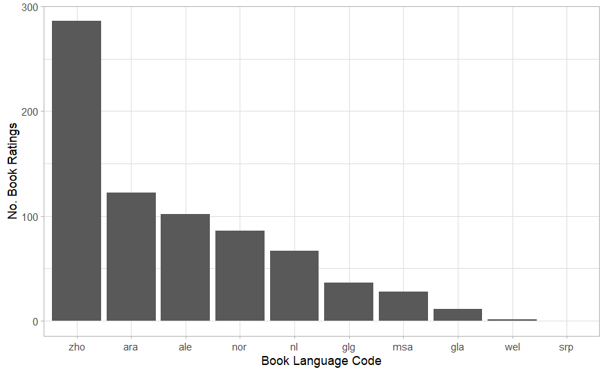

```r
xaxis_order <- c("zho", "ara", "ale", "nor", "nl",
                 "glg", "msa", "gla", "wel", "srp")
#  xaxis_order sets up a character vector to manually feed the data into ggplot in the order I want, rather than the default alphabetical order.  Is there a more concise way to do this within ggplot?

rates_chart <- rate_count_low %>%
  ggplot()+
  geom_col(mapping = aes(x = factor(language_code2, level = xaxis_order),
                         y = rate_count_per_language)) +
  theme_light() +
  labs(x = "Book Language Code", y = "No. Book Ratings")


rates_chart
```

It looks like Serbian (srp) books have no ratings assigned to them and Welsh (wel) books only have one rating. Scottish Gaelic (gla) is also relatively low with only 11 ratings. This suggests wel and gla might be the top two highest scoring language groups by virtue of having a very small number of high scoring reviews, rather than any special writing ability by Welsh and Gaelic speakers!

Looking at the top 10 average page count by language;

```r
avg_pages_grouped <- books_grouped %>%
  group_by(language_code2) %>%
  summarise(avg_pagecount = mean(num_pages)) %>%
  slice_max(order_by = avg_pagecount, n = 10)



avg_pages_grouped
```

| language_code2 | avg_pagecount |
| --- | --- |
| enm | 1060.3333 |
| msa | 784.0000 |
| nl | 744.0000 |
| glg | 741.0000 |
| ale | 512.0000 |
| mul | 437.2632 |
| grc | 413.3636 |
| tur | 403.0000 |
| ita | 400.6000 |
| ger | 391.9798 |

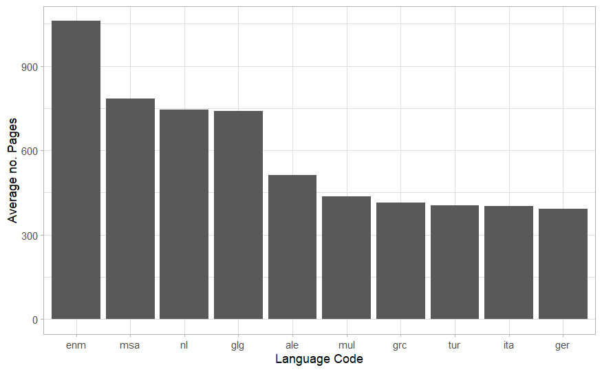

```r
xaxis_pagecount <- c("enm", "msa", "nl", "glg", "ale",
                     "mul", "grc", "tur", "ita", "ger")
# vector set up to manually reorder x-axis in ggplot below.  Descending order of data, rather than alphabetical order.

  avg_pages_chart <- avg_pages_grouped %>%
  ggplot()+
  geom_col(mapping = aes(x = factor(language_code2, levels = xaxis_pagecount),
                        y = avg_pagecount)) +
  theme_light() +
  labs(x = "Language Code", y = "Average no. Pages")

avg_pages_chart
```

The books with the highest average page count are written in Middle English (enm).

Group languages by similar sizes of books;

```r
books_grouped <- books_grouped %>%
  mutate(booksize = case_when(
                              mean(num_pages) <= 300 ~ "Small",
                              mean(num_pages) <= 500 ~ "Medium",
                              mean(num_pages) <= 700 ~ "Large",
                              mean(num_pages) >  700 ~ "X Large"
                              ))

books_grouped %>%
  select(title, language_code2, num_pages, booksize)
```

| title | language_code2 | num_pages | booksize |
| --- | --- | --- | --- |
| Harry Potter and the Half-Blood Prince (Harry Potter #6) | eng | 652 | Medium |
| Harry Potter and the Order of the Phoenix (Harry Potter #5) | eng | 870 | Medium |
| Harry Potter and the Chamber of Secrets (Harry Potter #2) | eng | 352 | Medium |
| Harry Potter and the Prisoner of Azkaban (Harry Potter #3) | eng | 435 | Medium |
| Harry Potter Boxed Set Books 1-5 (Harry Potter #1-5) | eng | 2690 | Medium |
| Unauthorized Harry Potter Book Seven News: Half-Blood Prince Analysis and Speculation | eng | 152 | Medium |
| Harry Potter Collection (Harry Potter #1-6) | eng | 3342 | Medium |
| The Ultimate Hitchhiker's Guide: Five Complete Novels and One Story (Hitchhiker's Guide to the Galaxy #1-5) | eng | 815 | Medium |
| The Ultimate Hitchhiker's Guide to the Galaxy (Hitchhiker's Guide to the Galaxy #1-5) | eng | 815 | Medium |
| The Hitchhiker's Guide to the Galaxy (Hitchhiker's Guide to the Galaxy #1) | eng | 215 | Medium |

[output cut: 990 more lines]

```r
NA
NA
```

Something that might have been useful earlier on is knowing how many books there are per language code;

```r
num_books_per_language <- books_grouped %>%
  group_by(language_code2) %>%
  summarise(num_books = n()) %>%
  arrange(-num_books)

num_books_per_language
```

| language_code2 | num_books |
| --- | --- |
| eng | 10537 |
| spa | 218 |
| fre | 144 |
| ger | 99 |
| jpn | 46 |
| mul | 19 |
| zho | 14 |
| grc | 11 |
| por | 10 |
| ita | 5 |

[output cut: 14 more lines]

```r
NA
```

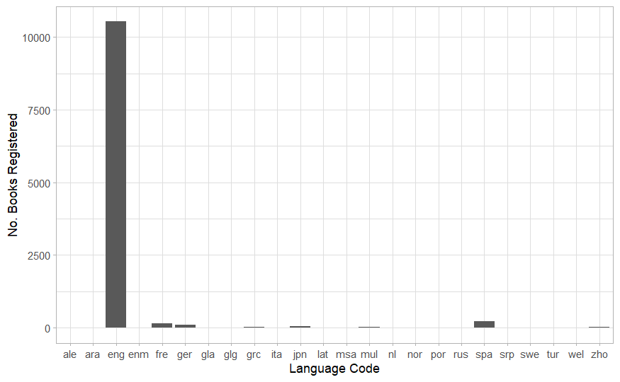

```r
num_books_chart <- num_books_per_language %>%
  ggplot()+
  geom_col(mapping = aes(x = factor(language_code2),
                         y = num_books)) +
  theme_light() +
  labs(x = "Language Code", y = "No. Books Registered")

num_books_chart
```

The chart above basically shows that the vast majority of books are in the english language, to the extent that the countries with fewer books disappear in the chart. Try a different chart type, e.g. a treemap;

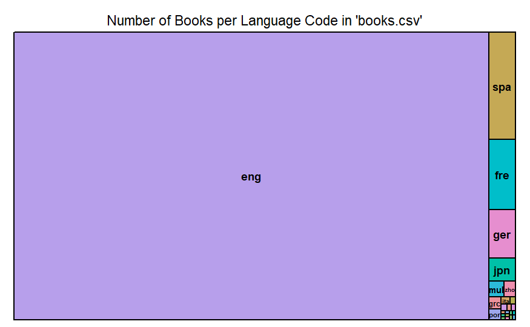

```r
treemap(num_books_per_language,
            index = "language_code2",
            vSize = "num_books",
            type = "index",
            title = "Number of Books per Language Code in 'books.csv'"
            )
```